# Spotify vs Apple Music — Review Analysis

# Introduction

This project explores the differences between the reviews of several music streaming apps, with a focus on comparing **Apple Music** and **Spotify**. Using Google Play review data, I examine how users talk about each app through a series of text-analysis steps. The project includes preprocessing the review text, analyzing word frequencies, generating word clouds, building word networks, comparing sentiment patterns, and extracting topics using both LDA and text embeddings.

By combining insights from these methods, I aim to uncover meaningful differences in how users perceive the two platforms and to translate these findings into valuable marketing insights.

# 1. Dataset Preparation

I started by loading all the packages necessary for this project.

```r
pkgs <- c("tm", "SnowballC", "dplyr", "wordcloud", "RWeka", "RColorBrewer", "tidyr",
          "igraph", "ggraph", "tidytext", "lubridate", "ggthemes", "ggplot2", "syuzhet",
          "plotly", "topicmodels", "text2vec", "word2vec", "proxy", "umap", "ggrepel")

install_if_missing <- function(p) if (!require(p,character.only=TRUE))
  install.packages(p, repos="https://cran.r-project.org")
invisible(lapply(pkgs, install_if_missing))


library(tm); library(SnowballC); library(dplyr); library(wordcloud);
library(RWeka); library(RColorBrewer); library(tidyr); library(igraph);
library(ggraph); library(tidytext); library(lubridate); library(ggthemes);
library(ggplot2); library(syuzhet); library(plotly); library(topicmodels);
library(text2vec); library(word2vec); library(proxy); library(umap)
```

The dataset used for this project contains Google Play reviews for several music streaming applications. For my analysis, I focused on reviews of Spotify and Apple Music. Therefore, I used a subset of 29,994 observations. Each entry includes the app name, user review text, star rating, app version, and timestamp. After filtering out all other apps, I obtained 14,999 Spotify reviews and 14,995 Apple Music reviews, which form the basis for all subsequent preprocessing and analysis steps.

```r
options(stringsAsFactors = FALSE)
reviews <- read.csv("google_play_music_reviews.csv")
str(reviews)
```

```
## 'data.frame':    76525 obs. of  5 variables:
##  $ app    : chr  "Spotify" "Spotify" "Spotify" "Spotify" ...
##  $ review : chr  "great" "5 star if u have premium" "too many ads" "adds" ...
##  $ rating : int  5 5 1 1 5 4 1 5 5 1 ...
##  $ version: chr  "9.0.42.529" "8.6.82.1113" "8.9.96.476" "" ...
##  $ date   : chr  "2025-05-22 11:58:57" "2025-05-22 11:58:46" "2025-05-22 11:57:00" "2025-05-22 11:52:40" ...
```

```r
data <- reviews[(reviews$app == "Spotify") | (reviews$app == "Apple Music"), ]
cat("\n The number of reviews for Spotify and Apple Music:\n", dim(data))
```

```
##
##  The number of reviews for Spotify and Apple Music:
##  29994 5
```

```r
cat("\n Spotify reviews:", sum(data$app == "Spotify"))
```

```
##
##  Spotify reviews: 14999
```

```r
cat("\n Apple Music reviews:", sum(data$app == "Apple Music"))
```

```
##
##  Apple Music reviews: 14995
```

# 2. Text preprocessing

I applied a standardized preprocessing pipeline to all review text before analysis. This included converting text to lowercase, removing stopwords, punctuation, numbers, and excess whitespace, and applying stemming to reduce words to their root forms. The procedure was performed separately for Spotify and Apple Music reviews, and a combined cleaned corpus was created for tasks requiring both datasets. These preprocessed texts will be used for most of the other tasks, while some methods will require different/additional preprocessing approaches.

```r
preprocess_basic <- function(text_vec) {
  corpus <- VCorpus(VectorSource(text_vec))

  corpus <- tm_map(corpus, content_transformer(tolower))
  corpus <- tm_map(corpus, removeWords, stopwords("english"))
  corpus <- tm_map(corpus, removePunctuation)
  corpus <- tm_map(corpus, stripWhitespace)
  corpus <- tm_map(corpus, removeNumbers)
  corpus <- tm_map(corpus, stemDocument)

  return(corpus)
}

# Create separate datasets for the two apps
spotify_text <- data$review[data$app == "Spotify"]
apple_text   <- data$review[data$app == "Apple Music"]

# Preprocess each using the function we defined
spotify_clean <- preprocess_basic(spotify_text)
apple_clean   <- preprocess_basic(apple_text)

corpus_spotify <- preprocess_basic(spotify_text)
corpus_apple   <- preprocess_basic(apple_text)

# Combine into one for some tasks
corpus_clean <- c(spotify_clean, apple_clean)
```

# 3. Words frequency

To examine the most frequently used terms in the reviews, I constructed document–term matrices for Spotify, Apple Music, and the combined corpus. By summing term counts across documents, I identified the highest-frequency words for each review dataset and extracted the top ten words overall and per platform.

```r
# Create the Document-Term matrix
dtm_spotify <- DocumentTermMatrix(corpus_spotify)
dtm_apple   <- DocumentTermMatrix(corpus_apple)
dtm <- DocumentTermMatrix(corpus_clean)

freq_spotify <- colSums(as.matrix(dtm_spotify))
freq_apple   <- colSums(as.matrix(dtm_apple))
word_freq <- colSums(as.matrix(dtm))

# Show the top 10 most frequent words in reviews of both apps together and separately
results <- list(
  "Top 10 both"    = sort(word_freq, decreasing = TRUE)[1:10],
  "Top 10 Spotify" = sort(freq_spotify, decreasing = TRUE)[1:10],
  "Top 10 Apple"   = sort(freq_apple, decreasing = TRUE)[1:10]
)

results
```

```
## $`Top 10 both`
##     app   music    song    good    appl    play spotifi     use    love  listen
##   10908    8861    6524    4014    3954    3705    3096    3006    2657    2624
##
## $`Top 10 Spotify`
##     app    song   music    good spotifi    play premium  listen    love    like
##    5181    3893    3339    2268    2113    1745    1719    1705    1573    1383
##
## $`Top 10 Apple`
##     app   music    appl    song    play    good     use    work android    just
##    5727    5522    3900    2631    1960    1746    1723    1503    1496    1310
```

## Word Frequency Analysis

Across both apps, general terms such as app, music, and song dominate the vocabulary. Spotify’s most frequent words emphasize playback, premium features and positive adjectives, while Apple Music’s top terms include more platform-specific mentions such as apple and android, as well as verbs for the app functionality. This reflects differences in user focus and context across the two review sets, which I continued to explore through further analysis.

# 4. Comparison and Commonality Clouds

As the next step, I generated comparison and commonality clouds to examine how frequently specific words and phrases appeared across the two apps. After preprocessing the text, I constructed term–document matrices for both one-gram and two-gram tokens and aggregated the total frequencies for Spotify and Apple Music. These matrices were combined into joint frequency tables, which allowed me to directly compare shared vocabulary as well as terms that appeared predominantly in one set of the reviews. Together, the created commonality clouds and comparison clouds provided an overview of linguistic similarities and differences in how users talk about Spotify and Apple Music.

## One-gram tokens

```r
# Create Term-Document Matrix
tdm_spotify <- TermDocumentMatrix(corpus_spotify)
tdm_apple   <- TermDocumentMatrix(corpus_apple)

# Convert to matrices
tdm_spotify_matrix <- as.matrix(tdm_spotify)
tdm_apple_matrix   <- as.matrix(tdm_apple)

# Aggregate term frequencies across all documents for each app
spotify_terms <- rowSums(tdm_spotify_matrix)
apple_terms   <- rowSums(tdm_apple_matrix)

# Combine into a single matrix with two columns
all_terms <- union(names(spotify_terms), names(apple_terms))
tdm_combined <- matrix(0, nrow = length(all_terms), ncol = 2)
rownames(tdm_combined) <- all_terms
colnames(tdm_combined) <- c("Spotify", "Apple Music")

tdm_combined[names(spotify_terms), "Spotify"] <- spotify_terms
tdm_combined[names(apple_terms), "Apple Music"] <- apple_terms
```

### Commonality Cloud

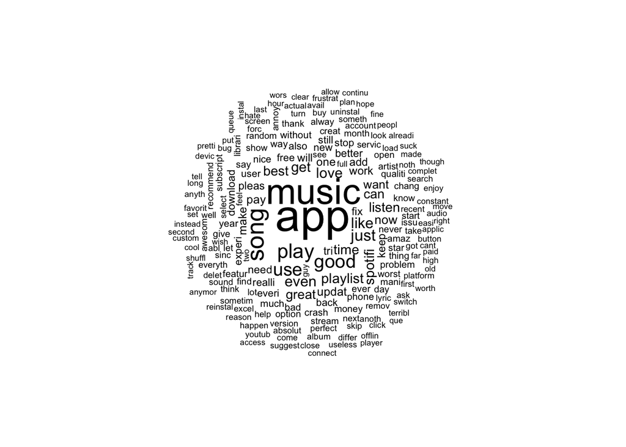

```r
commonality.cloud(tdm_combined, max.words=200, scale = c(3, 0.5),
                  random.order=FALSE)
```

### Comparison Cloud

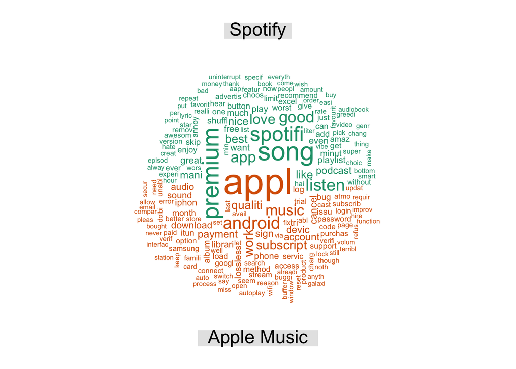

```r
comparison.cloud(tdm_combined, max.words=200, scale = c(3, 0.5),
                 random.order=FALSE, title.size=1.5)
```

## Bi-gram tokens

```r
# Define bigram tokenizer
Bigram_Tokenizer <- function(x) {
  NGramTokenizer(x, Weka_control(min = 2, max = 2))
}

# Create Term-Document Matrix with bigrams
tdm_bigram_spotify <- TermDocumentMatrix(corpus_spotify,
                                         control = list(tokenize = Bigram_Tokenizer))
tdm_bigram_apple   <- TermDocumentMatrix(corpus_apple,
                                         control = list(tokenize = Bigram_Tokenizer))

# Remove sparse terms
tdm_bigram_spotify <- removeSparseTerms(tdm_bigram_spotify, 0.998)
tdm_bigram_apple   <- removeSparseTerms(tdm_bigram_apple, 0.998)

# Convert to matrices
tdm_bigram_spotify_matrix <- as.matrix(tdm_bigram_spotify)
tdm_bigram_apple_matrix   <- as.matrix(tdm_bigram_apple)

spotify_bigrams <- rowSums(tdm_bigram_spotify_matrix)
apple_bigrams   <- rowSums(tdm_bigram_apple_matrix)

# Combine into single matrix
all_bigrams <- union(names(spotify_bigrams), names(apple_bigrams))
tdm_bigram_combined <- matrix(0, nrow = length(all_bigrams), ncol = 2)
rownames(tdm_bigram_combined) <- all_bigrams
colnames(tdm_bigram_combined) <- c("Spotify", "Apple Music")

tdm_bigram_combined[names(spotify_bigrams), "Spotify"] <- spotify_bigrams
tdm_bigram_combined[names(apple_bigrams), "Apple Music"] <- apple_bigrams
```

### Commonality Cloud

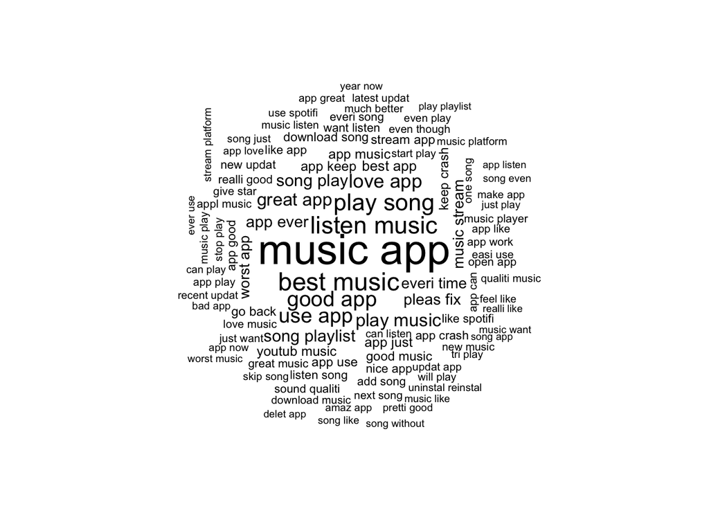

```r
commonality.cloud(tdm_bigram_combined, max.words=150, scale = c(2.5, 0.5),
                  random.order=FALSE)
```

### Comparison Cloud

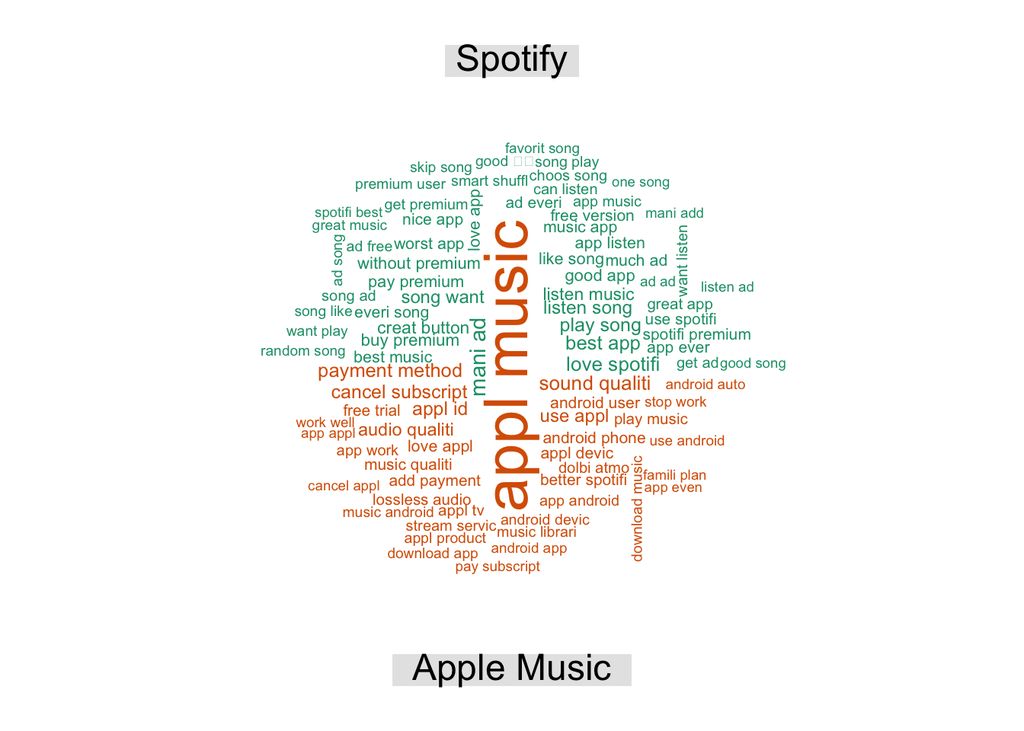

```r
comparison.cloud(tdm_bigram_combined, max.words=90, scale = c(2.5, 0.5),
                 random.order=FALSE, title.size=1.5)
```

## Cloud Graphs Analysis

The commonality clouds show that core concepts such as app, music, song, play, and listen dominate user discourse. This indicates that despite differences in platform features and customer experiences, users of both apps consistently frame their experiences around basic listening tasks. Phrases like play song, good app, and listen music appear prominently, reinforcing that basic functionality is at the center of most user reviews.

By contrast, the Apple Music comparison clouds highlight vocabulary centered around payment, subscription, cancel, method, and audio quality. These patterns represent concerns about billing processes, account verification, or navigating free trials. Terms such as lossless audio and sound qualit also indicate that audio quality is a more prominent theme in Apple Music feedback than in the Spotify reviews. Compared to Spotify’s emphasis on ads and playback control, Apple Music comments show a stronger focus on service management and technical performance across devices.

Overall, the commonality and comparison clouds reveal that while both user groups share a core vocabulary tied to music playback, Spotify reviews prioritize everyday usability and premium barriers, whereas Apple Music reviews center on subscription logistics and sound quality.

# 5. Wordnetwork

To explore the relationships between words in the reviews, I constructed bigram and trigram networks for both Spotify and Apple Music. After generating the n-grams from the preprocessed text, I converted the resulting frequency lists into data frames and separated each n-gram into its component words.

For bigrams, pairs of adjacent terms were used to build edge lists, which were then converted into graph objects using igraph. To focus on the most important connections, I applied a frequency threshold of 70, keeping only high-occurrence bigrams in each dataset.

For trigrams, I created a trigram term–document matrix using a custom tokenizer. After removing sparse trigrams and computing their frequencies, I separated each trigram into three individual words. I then constructed directed edges by treating the first two words as the source and the third word as the target. I applied a frequency cutoff of 3, which allowed me to highlight only recurring expressions.

For both bigrams and trigrams, the networks were then plotted, revealing the most prominent two- and three-word patterns.

## Networks for Bigrams

```r
# Create bigram frequency data frames using the bigrams I already calculated
spotify_bigram_df <- data.frame(word = names(spotify_bigrams),
                                freq = spotify_bigrams,
                                stringsAsFactors = FALSE)

apple_bigram_df <- data.frame(word = names(apple_bigrams),
                              freq = apple_bigrams,
                              stringsAsFactors = FALSE)

# Separate bigrams into two words
spotify_separated <- spotify_bigram_df %>%
  separate(word, c("word1", "word2"), sep = " ")

apple_separated <- apple_bigram_df %>%
  separate(word, c("word1", "word2"), sep = " ")

# I use the threshold of frequency = 70
word.network_spotify <- spotify_separated %>%
  filter(freq > 70) %>%
  graph_from_data_frame()

word.network_apple <- apple_separated %>%
  filter(freq > 70) %>%
  graph_from_data_frame()
```

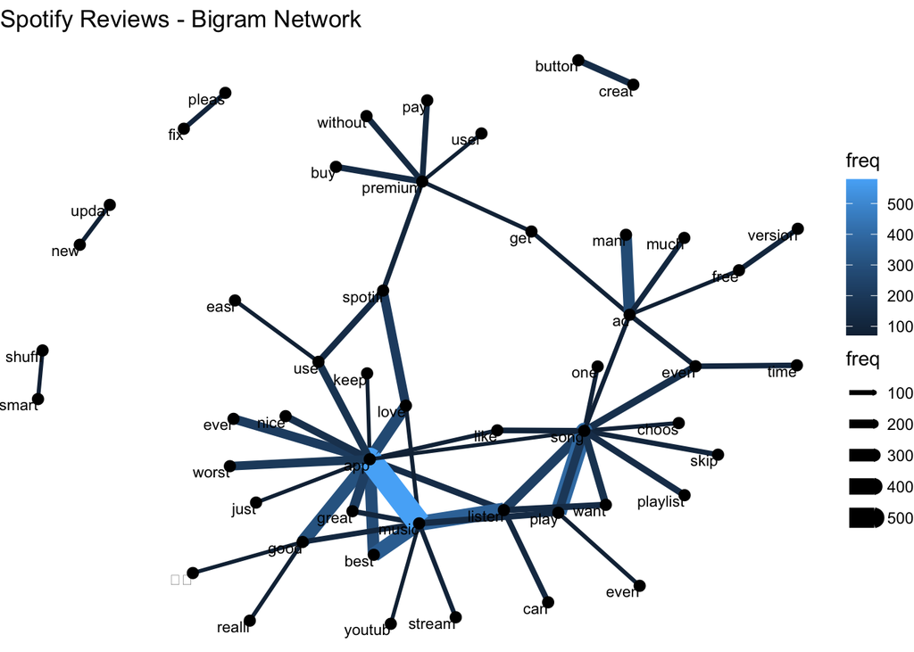

```r
a <- arrow(angle = 20, length = unit(0.05, "cm"), ends = "last", type = "open")

ggraph(word.network_spotify, layout = "fr") +
  geom_edge_link(aes(color = freq, width = freq), arrow = a) +
  geom_node_point(size = 2.5) +
  geom_node_text(aes(label = name), vjust = 1, hjust = 1, size = 3) +
  labs(title = "Spotify Reviews - Bigram Network") +
  theme_void()
```

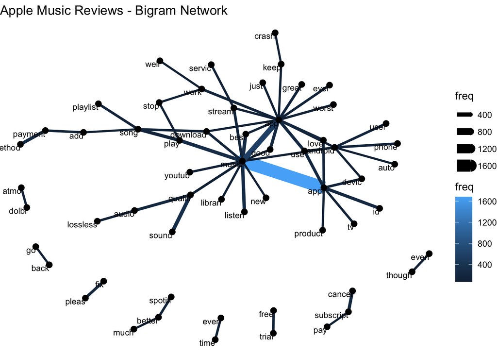

```r
ggraph(word.network_apple, layout = "fr") +
  geom_edge_link(aes(color = freq, width = freq), arrow = a) +
  geom_node_point(size = 2.5) +
  geom_node_text(aes(label = name), vjust = 1, hjust = 1, size = 3) +
  labs(title = "Apple Music Reviews - Bigram Network") +
  theme_void()
```

## Networks for Trigrams

```r
# Define trigram tokenizer
Trigram_Tokenizer <- function(x) {
  NGramTokenizer(x, Weka_control(min = 3, max = 3))
}

# Create trigram Term-Document Matrix
tdm_trigram_spotify <- TermDocumentMatrix(corpus_spotify,
                                          control = list(tokenize = Trigram_Tokenizer))
tdm_trigram_apple <- TermDocumentMatrix(corpus_apple,
                                        control = list(tokenize = Trigram_Tokenizer))

# Remove sparse terms
tdm_trigram_spotify <- removeSparseTerms(tdm_trigram_spotify, 0.998)
tdm_trigram_apple <- removeSparseTerms(tdm_trigram_apple, 0.998)

# Convert to matrix
tdm_trigram_spotify_m <- as.matrix(tdm_trigram_spotify)
tdm_trigram_apple_m <- as.matrix(tdm_trigram_apple)

# Calculate trigram frequencies
v_tri_spotify <- sort(rowSums(tdm_trigram_spotify_m), decreasing = TRUE)
v_tri_apple <- sort(rowSums(tdm_trigram_apple_m), decreasing = TRUE)

# Create data frames with column name "word"
d_tri_spotify <- data.frame(word = names(v_tri_spotify), freq = v_tri_spotify, stringsAsFactors = FALSE)
d_tri_apple <- data.frame(word = names(v_tri_apple), freq = v_tri_apple, stringsAsFactors = FALSE)
```

```r
# Separate three words and build edge lists for Spotify
d_sep_tri_spotify <- d_tri_spotify %>%
  separate(word, c("word1", "word2", "word3"), sep = " ")

d_edges_tri_spotify <- d_sep_tri_spotify %>%
  mutate(source = paste(word1, word2, sep = " "),
         target = word3) %>%
  select(source, target, freq)

# Filter frequent trigrams
d_edges_tri_spotify_filt <- d_edges_tri_spotify %>% filter(freq > 3)

# Separate three words and build edge lists for Apple Music
d_sep_tri_apple <- d_tri_apple %>%
  separate(word, c("word1", "word2", "word3"), sep = " ")

d_edges_tri_apple <- d_sep_tri_apple %>%
  mutate(source = paste(word1, word2, sep = " "),
         target = word3) %>%
  select(source, target, freq)

# Filter frequent trigrams
d_edges_tri_apple_filt <- d_edges_tri_apple %>% filter(freq > 3)
```

## Spotify Trigram Network

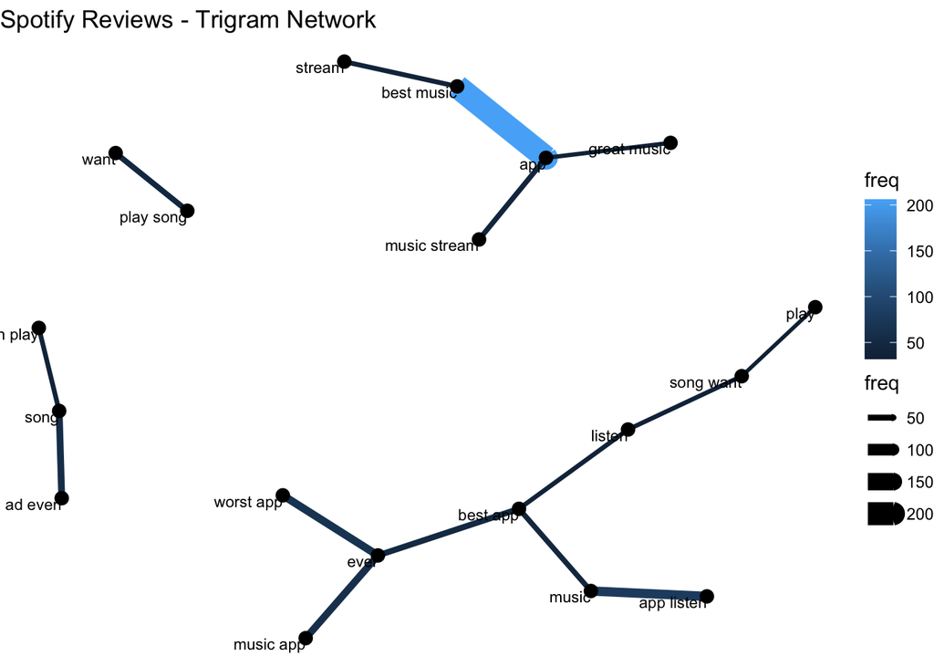

```r
word.network_spotify_tri <- graph_from_data_frame(d_edges_tri_spotify_filt, directed = TRUE)

ggraph(word.network_spotify_tri, layout = "fr") +
  geom_edge_link(aes(color = freq, width = freq), arrow = a) +
  geom_node_point(size = 3) +
  geom_node_text(aes(label = name), vjust = 1, hjust = 1, size = 3) +
  labs(title = "Spotify Reviews - Trigram Network") +
  theme_void()
```

## Apple Music Trigram Network

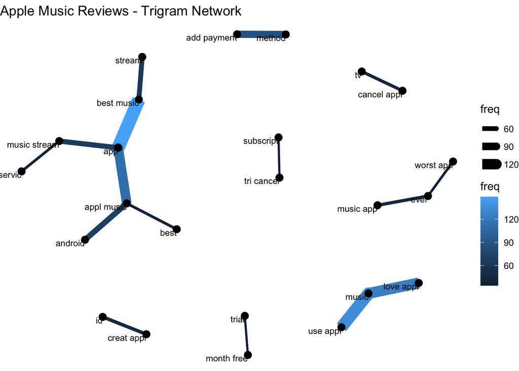

```r
word.network_apple_tri <- graph_from_data_frame(d_edges_tri_apple_filt, directed = TRUE)

ggraph(word.network_apple_tri, layout = "fr") +
  geom_edge_link(aes(color = freq, width = freq), arrow = a) +
  geom_node_point(size = 3) +
  geom_node_text(aes(label = name), vjust = 1, hjust = 1, size = 3) +
  labs(title = "Apple Music Reviews - Trigram Network") +
  theme_void()
```

## Networks Analysis

Taken together, the combined bigram and trigram networks show that Spotify reviews emphasize the user experience concerning the app functionality, playlists, streaming consistency, and the balance between free and premium, while Apple Music reviews highlight technical integration, device compatibility, and especially subscription and payment management.

# 6. Sentiment

I conducted sentiment analysis on the reviews using a lexicon-based approach. After preprocessing the text to remove stopwords, punctuation, numbers, and excess whitespace, I constructed a document–term matrix and matched each token to the sentiment categories provided by the sentiments dataset. This way I identified positive and negative words within each review and computed a polarity score. By combining the sentiment information with date metadata for each document, I was able to evaluate both overall sentiment differences between apps and changes in polarity over time.

```r
data("sentiments")

# content from both apps
content <- as.character(data$review)

# convert timestamp to date
date_info <- data.frame(
  document = 1:nrow(data),
  app = data$app,
  review_date = as.Date(data$date)
)


# Preprocess
content_corpus <- VCorpus(VectorSource(content))
content_corpus <- tm_map(content_corpus, content_transformer(tolower))
content_corpus <- tm_map(content_corpus, removeNumbers)
content_corpus <- tm_map(content_corpus, removeWords, stopwords("english"))
content_corpus <- tm_map(content_corpus, removePunctuation)
content_corpus <- tm_map(content_corpus, stripWhitespace)

# Create document-term matrix
corpus.dtm <- DocumentTermMatrix(content_corpus)
corpus.tidy <- tidy(corpus.dtm)
corpus.tidy$count <- as.numeric(corpus.tidy$count)
colnames(corpus.tidy)[2] <- 'word'
corpus.tidy$document <- as.numeric(corpus.tidy$document)

corpus.sentiment <- inner_join(corpus.tidy, sentiments, by = "word")
corpus.sentiment <- count(corpus.sentiment, sentiment, index = document)
corpus.sentiment <- spread(corpus.sentiment, sentiment, n, fill = 0)
corpus.sentiment <- left_join(corpus.sentiment, date_info, by = c("index" = "document"))

# Calculate polarity
corpus.sentiment$polarity <- corpus.sentiment$positive - corpus.sentiment$negative
corpus.sentiment$pos <- ifelse(corpus.sentiment$polarity >= 0, "pos", "neg")
```

## Average Sentiment by App

```r
# Calculate average sentiment by app
avg_sentiment <- corpus.sentiment %>%
  group_by(app) %>%
  summarise(
    avg_polarity = mean(polarity, na.rm = TRUE),
    total_positive = sum(positive, na.rm = TRUE),
    total_negative = sum(negative, na.rm = TRUE),
    n_reviews = n()
  )

print(avg_sentiment)
```

```
## # A tibble: 2 × 5
##   app         avg_polarity total_positive total_negative n_reviews
##   <chr>              <dbl>          <dbl>          <dbl>     <int>
## 1 Apple Music        0.441          14192           9160     11408
## 2 Spotify            0.728          14729           6055     11923
```

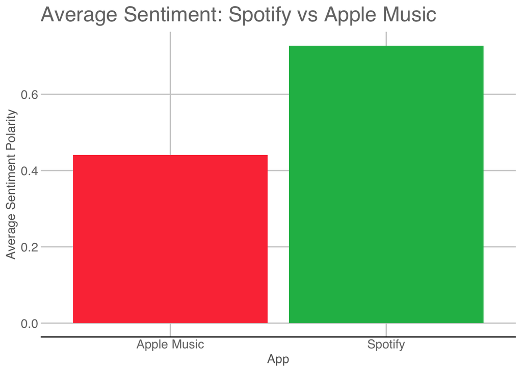

```r
# Plot average sentiment
ggplot(avg_sentiment, aes(x = app, y = avg_polarity, fill = app)) +
  geom_bar(stat = "identity") +
  scale_fill_manual(values = c("Spotify" = "#1DB954", "Apple Music" = "#FC3C44")) +
  theme_gdocs() +
  labs(title = "Average Sentiment: Spotify vs Apple Music",
       x = "App",
       y = "Average Sentiment Polarity") +
  theme(legend.position = "none")
```

## Sentiment over Time (Smoothed)

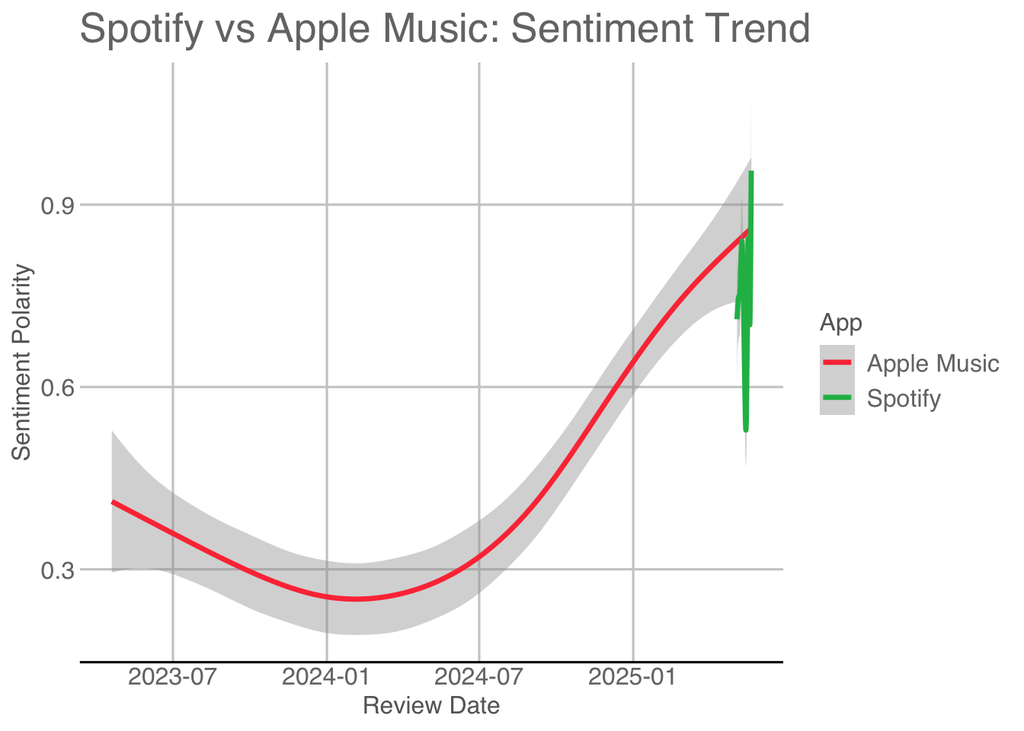

```r
ggplot(corpus.sentiment, aes(x = review_date, y = polarity, color = app)) +
  stat_smooth(se = TRUE, linewidth = 1.2) +
  scale_color_manual(values = c("Spotify" = "#1DB954", "Apple Music" = "#FC3C44")) +
  theme_gdocs() +
  labs(title = "Spotify vs Apple Music: Sentiment Trend",
       x = "Review Date",
       y = "Sentiment Polarity",
       color = "App")
```

## Sentiment over Time - Spotify

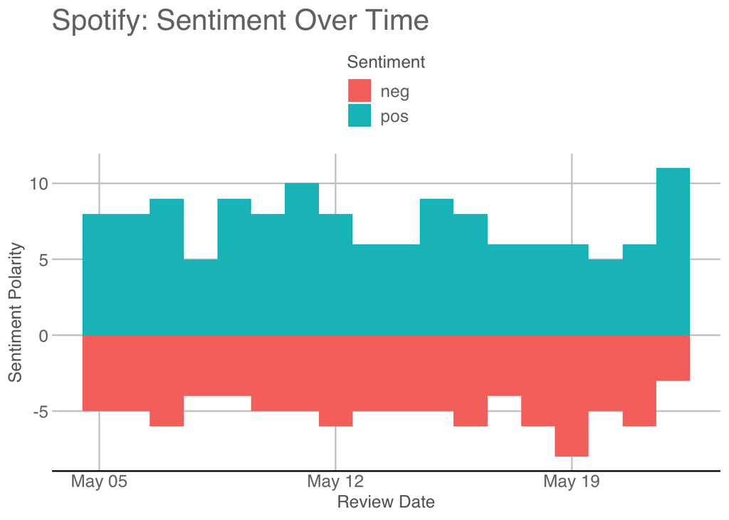

```r
corpus.sentiment.spotify <- corpus.sentiment %>% filter(app == "Spotify")

ggplot(corpus.sentiment.spotify, aes(x = review_date, y = polarity, fill = pos)) +
  geom_bar(stat = "identity", position = "identity", width = 1) +
  theme_gdocs() +
  labs(title = "Spotify: Sentiment Over Time",
       x = "Review Date",
       y = "Sentiment Polarity",
       fill = "Sentiment") +
  theme(legend.position = "top")
```

## Sentiment over Time - Spotify (Smoothed)

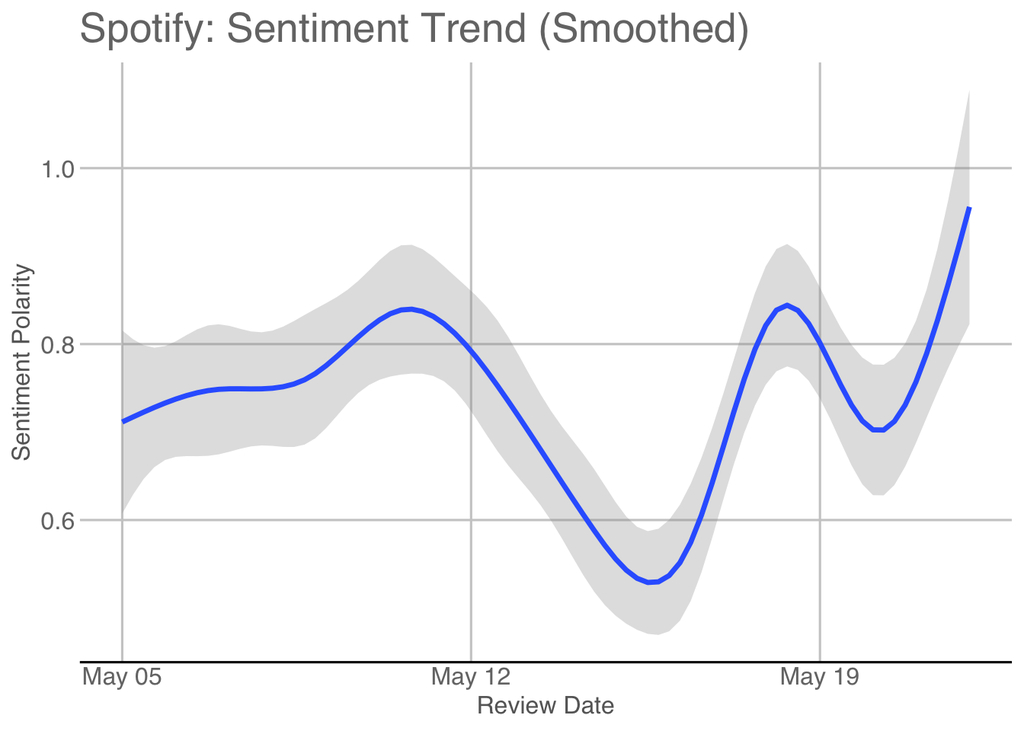

```r
ggplot(corpus.sentiment.spotify, aes(x = review_date, y = polarity)) +
  stat_smooth(alpha = 0.3, size = 1.2) +
  theme_gdocs() +
  labs(title = "Spotify: Sentiment Trend (Smoothed)",
       x = "Review Date",
       y = "Sentiment Polarity")
```

## Sentiment over Time - Apple Music

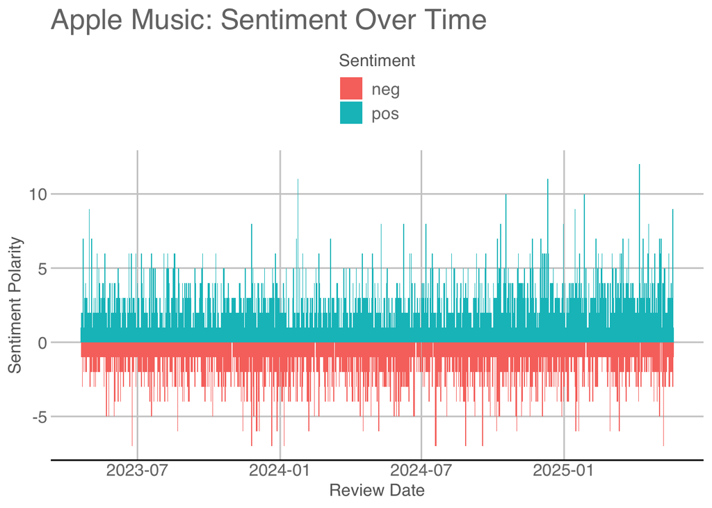

```r
corpus.sentiment.apple <- corpus.sentiment %>% filter(app == "Apple Music")

ggplot(corpus.sentiment.apple, aes(x = review_date, y = polarity, fill = pos)) +
  geom_bar(stat = "identity", position = "identity", width = 1) +
  theme_gdocs() +
  labs(title = "Apple Music: Sentiment Over Time",
       x = "Review Date",
       y = "Sentiment Polarity",
       fill = "Sentiment") +
  theme(legend.position = "top")
```

## Sentiment over Time - Apple Music (Smoothed)

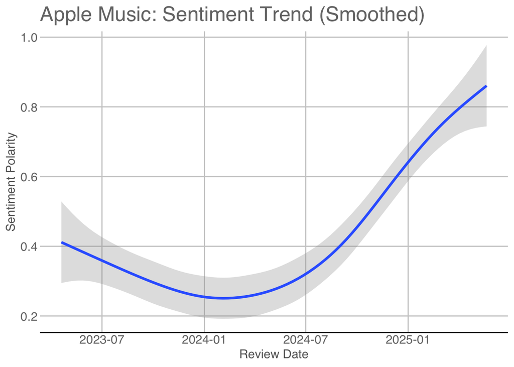

```r
ggplot(corpus.sentiment.apple, aes(x = review_date, y = polarity)) +
  stat_smooth(alpha = 0.3, size = 1.2) +
  theme_gdocs() +
  labs(title = "Apple Music: Sentiment Trend (Smoothed)",
       x = "Review Date",
       y = "Sentiment Polarity")
```

## Sentiment Analysis

Overall sentiment patterns differ noticeably between the two platforms. The average polarity scores show a clear gap: **Spotify reviews are substantially more positive on average (0.73) than Apple Music reviews (0.44)**. While both apps receive far more positive than negative tokens in the aggregated counts, Spotify reviews contain fewer negative terms relative to their volume.

When examining sentiment over time, the raw bar charts of positive and negative counts appear nearly balanced and offer little interpretive value. For **Spotify**, the smoothed series (which starts only in 2025 in this dataset) remains consistently positive, dropping and increasing again at several points in time, and ending with an upward shift. This suggests that the tone of Spotify feedback is steady and generally positive.

**Apple Music** shows a longer timeline beginning in 2023. Its smoothed trend starts at a moderate positive level, dips from late 2023 until early 2024, and then increases steadily throughout 2024 into 2025. This demonstrates that sentiment declined for a period before improving substantially over time. The broader temporal context for Apple Music makes the trend more interpretable and useful, whereas the joint smoothed plot for both apps does not provide much value since the Spotify data begins much later.

Taken together, the sentiment patterns reinforce the distinctions seen in the topic modeling: Spotify feedback is consistently more positive, whereas Apple Music reviews show more variability over time, aligning with recurring themes of technical issues and subscription frustrations. Despite differences in coverage and the limitations of lexicon-based scoring, the sentiment results provide a coherent picture of how users evaluate each service.

# 7. LDA

I applied Latent Dirichlet Allocation (LDA) to Spotify and Apple Music reviews using both unigrams and bigrams. Empty documents were removed from the document-term matrices to avoid errors caused by preprocessing. Four topics were chosen for each app as a balance between detail and interpretability. The unigram models captured general themes, while bigram models highlighted recurring phrases. To validate and refine results, I also used the text2vec framework, which prunes vocabulary and often produces clearer topic boundaries.

## LDA with unigrams

```r
# For Spotify
row_sums_spotify <- slam::row_sums(dtm_spotify)
dtm_spotify_clean <- dtm_spotify[row_sums_spotify > 0, ]

cat("Spotify reviews removed:", sum(row_sums_spotify == 0), "out of", length(row_sums_spotify), "\n")
```

```
## Spotify reviews removed: 264 out of 14999
```

```r
# For Apple Music
row_sums_apple <- slam::row_sums(dtm_apple)
dtm_apple_clean <- dtm_apple[row_sums_apple > 0, ]

cat("Apple Music reviews removed:", sum(row_sums_apple == 0), "out of", length(row_sums_apple), "\n")
```

```
## Apple Music reviews removed: 191 out of 14995
```

```r
set.seed(123)
lda_spotify <- LDA(dtm_spotify_clean, k = 4, control = list(seed = 123))
lda_apple   <- LDA(dtm_apple_clean, k = 4, control = list(seed = 123))

cat(" Topics for Spotify:\n")
```

```
##  Topics for Spotify:
```

```r
terms(lda_spotify, 8)   # top 8 words per topic for Spotify
```

```
##      Topic 1   Topic 2   Topic 3   Topic 4
## [1,] "app"     "song"    "app"     "app"
## [2,] "music"   "spotifi" "use"     "song"
## [3,] "good"    "good"    "premium" "music"
## [4,] "premium" "play"    "like"    "spotifi"
## [5,] "song"    "love"    "spotifi" "playlist"
## [6,] "just"    "listen"  "want"    "play"
## [7,] "best"    "music"   "best"    "great"
## [8,] "play"    "even"    "music"   "like"
```

```r
cat("\n Topics for Apple Music:\n")
```

```
##
##  Topics for Apple Music:
```

```r
terms(lda_apple, 8)     # top 8 words per topic for Apple Music
```

```
##      Topic 1 Topic 2   Topic 3   Topic 4
## [1,] "music" "music"   "music"   "app"
## [2,] "app"   "song"    "app"     "appl"
## [3,] "play"  "work"    "appl"    "subscript"
## [4,] "song"  "good"    "song"    "tri"
## [5,] "appl"  "play"    "use"     "music"
## [6,] "use"   "appl"    "good"    "time"
## [7,] "even"  "like"    "android" "use"
## [8,] "just"  "android" "can"     "sign"
```

**Apple Music:**

- Topic 1: General music playback (“music”, “app”, “play”, “song”)
- Topic 2: Technical issues (“work”, “good”, “like”, “android”)
- Topic 3: Platform issues (“music”, “appl”, “android”, “can”)
- Topic 4: Subscription problems (“app”, “appl”, “subscript”, “tri”, “sign”)

## LDA with bigrams

```r
dtm_bigram_spotify <- DocumentTermMatrix(corpus_spotify, control = list(tokenize = Bigram_Tokenizer))
dtm_bigram_apple   <- DocumentTermMatrix(corpus_apple, control = list(tokenize = Bigram_Tokenizer))

# remove sparse terms to manage size
dtm_bigram_spotify <- removeSparseTerms(dtm_bigram_spotify, 0.998)
dtm_bigram_apple   <- removeSparseTerms(dtm_bigram_apple, 0.998)

# remove empty documents
row_sums_spotify_bigram <- slam::row_sums(dtm_bigram_spotify)
dtm_bigram_spotify_clean <- dtm_bigram_spotify[row_sums_spotify_bigram > 0, ]

row_sums_apple_bigram <- slam::row_sums(dtm_bigram_apple)
dtm_bigram_apple_clean <- dtm_bigram_apple[row_sums_apple_bigram > 0, ]
```

```r
set.seed(123)
lda_spotify_bigram <- LDA(dtm_bigram_spotify_clean, k = 4, control = list(seed = 123))
lda_apple_bigram   <- LDA(dtm_bigram_apple_clean, k = 4, control = list(seed = 123))

cat(" Bigram Topics for Spotify:\n")
```

```
##  Bigram Topics for Spotify:
```

```r
t_s <- terms(lda_spotify_bigram, 6) # top 6 bigrams per topic for Spotify
print(t_s)
```

```
##      Topic 1        Topic 2        Topic 3        Topic 4
## [1,] "play song"    "play song"    "music app"    "music app"
## [2,] "listen music" "good app"     "listen music" "good app"
## [3,] "best app"     "best music"   "best music"   "best app"
## [4,] "best music"   "great app"    "love app"     "great app"
## [5,] "mani ad"      "love spotifi" "app listen"   "listen music"
## [6,] "buy premium"  "song like"    "listen song"  "love app"
```

```r
cat("\n Bigram Topics for Apple Music:\n")
```

```
##
##  Bigram Topics for Apple Music:
```

```r
t_a <- terms(lda_apple_bigram, 6)  # top 6 bigrams per topic for Apple Music
print(t_a)
```

```
##      Topic 1            Topic 2         Topic 3         Topic 4
## [1,] "appl music"       "appl music"    "appl music"    "appl music"
## [2,] "audio qualiti"    "play song"     "use app"       "music app"
## [3,] "music app"        "sound qualiti" "music app"     "payment method"
## [4,] "cancel subscript" "best music"    "play music"    "listen music"
## [5,] "play music"       "appl id"       "sound qualiti" "add payment"
## [6,] "payment method"   "good app"      "love app"      "app ever"
```

## Comparison to text2vec

### For Spotify

```r
spotify_cleaned_text <- sapply(corpus_spotify, as.character)

# For Spotify
it_spotify <- itoken(spotify_cleaned_text,
                     tokenizer = word_tokenizer,
                     progressbar = FALSE)

vocab_spotify <- create_vocabulary(it_spotify, ngram = c(1L, 2L)) %>%
  prune_vocabulary(term_count_min = 5, doc_proportion_max = 0.5)

vectorizer_spotify <- vocab_vectorizer(vocab_spotify)
dtm_text2vec_spotify <- create_dtm(it_spotify, vectorizer_spotify)

lda_spotify_text2vec <- LDA$new(n_topics = 4, doc_topic_prior = 0.1, topic_word_prior = 0.01)
doc_topic_spotify <- lda_spotify_text2vec$fit_transform(dtm_text2vec_spotify,
                                                         n_iter = 1000,
                                                         convergence_tol = 0.001,
                                                         progressbar = FALSE)

cat("Text2vec Topics for Spotify:\n")
```

```
## Text2vec Topics for Spotify:
```

```r
print(lda_spotify_text2vec$get_top_words(n = 8, topic_number = 1:4))
```

```
##      [,1]      [,2]     [,3]      [,4]
## [1,] "app"     "ad"     "app"     "song"
## [2,] "music"   "app"    "spotifi" "play"
## [3,] "good"    "good"   "song"    "premium"
## [4,] "love"    "song"   "updat"   "like"
## [5,] "best"    "music"  "time"    "want"
## [6,] "great"   "listen" "play"    "listen"
## [7,] "spotifi" "mani"   "work"    "playlist"
## [8,] "nice"    "get"    "keep"    "even"
```

### For Apple Music

```r
apple_cleaned_text <- sapply(corpus_apple, as.character)
it_apple <- itoken(apple_cleaned_text,
                   tokenizer = word_tokenizer,
                   progressbar = FALSE)

vocab_apple <- create_vocabulary(it_apple, ngram = c(1L, 2L)) %>%
  prune_vocabulary(term_count_min = 5, doc_proportion_max = 0.5)

vectorizer_apple <- vocab_vectorizer(vocab_apple)
dtm_text2vec_apple <- create_dtm(it_apple, vectorizer_apple)

lda_apple_text2vec <- LDA$new(n_topics = 4, doc_topic_prior = 0.1, topic_word_prior = 0.01)
doc_topic_apple <- lda_apple_text2vec$fit_transform(dtm_text2vec_apple,
                                                     n_iter = 1000,
                                                     convergence_tol = 0.001,
                                                     progressbar = FALSE)

cat("Text2vec Topics for Apple Music:")
```

```
## Text2vec Topics for Apple Music:
```

```r
print(lda_apple_text2vec$get_top_words(n = 8, topic_number = 1:4))
```

```
##      [,1]      [,2]       [,3]        [,4]
## [1,] "app"     "song"     "appl"      "music"
## [2,] "music"   "play"     "app"       "app"
## [3,] "appl"    "music"    "work"      "good"
## [4,] "pay"     "playlist" "android"   "appl"
## [5,] "payment" "app"      "subscript" "qualiti"
## [6,] "use"     "like"     "account"   "love"
## [7,] "even"    "updat"    "music"     "best"
## [8,] "just"    "album"    "tri"       "appl_music"
```

## LDA Analysis

**Apple Music** topics emphasized general playback (music, play, song), technical issues (work, android, good), platform problems (appl, can, android), and subscription complaints (subscript, trial, sign).

Overall, topic modelling shows Spotify reviews mix enthusiasm with frustration over ads and features, while Apple Music reviews focus more consistently on technical integration and pricing issues.

# 8 Text Embeddings

In this analysis I used word embeddings to uncover the semantic structure of Spotify and Apple Music reviews. A Word2Vec model learned how words are used in context, and retrieving the most similar words to “spotify” and “apple” highlighted what users associate with each platform. Through UMAP visualizations I projected these embeddings into two dimensions, revealing clusters such as playback actions, sentiment words, and platform references. Semantic vector arithmetic (e.g., spotify + good − bad) identified words tied to positive or negative experiences, while a dendrogram grouped common words by similarity, mapping themes like usage, sentiment, and app features. K-means clustering further organized words into coherent data-driven topics, capturing themes such as positive sentiment, complaints, music content, and platform discussions.

## Similar Words to Spotify and Apple

```r
# Train Word2Vec model on the existing cleaned text

# Use my already cleaned text corpus:
all_reviews <- tolower(data$review)

set.seed(123)

model <- word2vec(
  x = all_reviews,
  type = "cbow",
  dim = 150,
  window = 5,
  iter = 25
)

# Find similar words to “spotify” and “apple”

sim_spotify <- predict(model, c("spotify"), type = "nearest", top_n = 10)
sim_apple   <- predict(model, c("apple"),   type = "nearest", top_n = 10)

cat("Similar to SPOTIFY:")
```

```
## Similar to SPOTIFY:
```

```r
print(sim_spotify)
```

```
## $spotify
##      term1   term2 similarity rank
## 1  spotify pandora  0.7360318    1
## 2  spotify youtube  0.6732567    2
## 3  spotify    this  0.6466199    3
## 4  spotify      yt  0.6230490    4
## 5  spotify      it  0.6213300    5
## 6  spotify   early  0.6046558    6
## 7  spotify  amazon  0.5998289    7
## 8  spotify   qobuz  0.5965785    8
## 9  spotify  iphone  0.5761515    9
## 10 spotify   tidal  0.5754654   10
```

```r
cat("Similar to APPLE:")
```

```
## Similar to APPLE:
```

```r
print(sim_apple)
```

```
## $apple
##    term1       term2 similarity rank
## 1  apple      icloud  0.6332060    1
## 2  apple      amazon  0.6305165    2
## 3  apple    physical  0.6097664    3
## 4  apple      owners  0.5923719    4
## 5  apple      airtel  0.5923108    5
## 6  apple differently  0.5898212    6
## 7  apple      google  0.5877293    7
## 8  apple    inactive  0.5840350    8
## 9  apple     iphones  0.5824182    9
## 10 apple     android  0.5821072   10
```

## UMAP Visualization of Word Embeddings

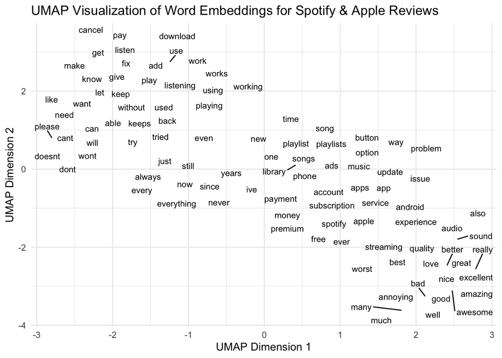

```r
# Extract vocabulary to embed and visualize

# Build a corpus using the cleaned text
embedding_corpus <- VCorpus(VectorSource(all_reviews)) %>%
  tm_map(removePunctuation) %>%
  tm_map(removeNumbers) %>%
  tm_map(removeWords, stopwords("english")) %>%
  tm_map(stripWhitespace)

dtm_embed <- DocumentTermMatrix(embedding_corpus)
words_all <- colnames(as.matrix(dtm_embed))

# Select a sample of 100 frequent words to avoid clutter
word_freqs <- colSums(as.matrix(dtm_embed))
top_words <- names(sort(word_freqs, decreasing = TRUE))[1:100]

# get embeddings
embeddings <- predict(model, newdata = top_words, type = "embedding")
embeddings <- na.omit(embeddings)

# Visualize embeddings using UMAP

umap_vis <- umap(embeddings, n_neighbors = 15, n_threads = 2)

df_embed <- data.frame(
  word = rownames(embeddings),
  x = umap_vis$layout[, 1],
  y = umap_vis$layout[, 2]
)

ggplot(df_embed, aes(x = x, y = y, label = word)) +
  geom_text_repel(size = 3, max.overlaps = 20) +  # Prevents overlapping labels
  labs(title = "UMAP Visualization of Word Embeddings for Spotify & Apple Reviews",
       x = "UMAP Dimension 1",
       y = "UMAP Dimension 2") +
  theme_minimal()
```

## Cluster Dendrogram

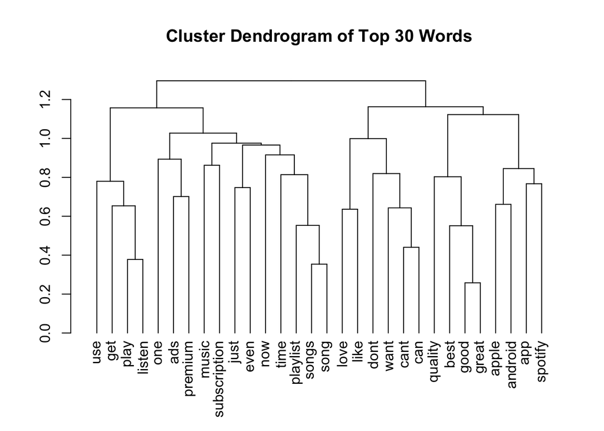

```r
top_words_dendro <- names(sort(word_freqs, decreasing = TRUE))[1:30]
embeddings_dendro <- predict(model, newdata = top_words_dendro, type = "embedding")
embeddings_dendro <- na.omit(embeddings_dendro)

cos_dist <- dist(embeddings_dendro, method = "cosine")
plot(
  as.dendrogram(hclust(cos_dist)),
  cex = 0.7,
  main = "Cluster Dendrogram of Top 30 Words"
)
```

## Semantic Vector Arithmetic: Spotify

```r
# Vector arithmetic examples

# Word directions: positive vs negative experience
w_good <- predict(model, "good", type = "embedding")
w_bad  <- predict(model, "bad",  type = "embedding")

# Spotify: good - bad direction
v_spotify <- predict(model, "spotify", type = "embedding")
spotify_semantic_shift <- v_spotify + w_good - w_bad

spotify_shift_nearest <- predict(
  model,
  newdata = spotify_semantic_shift,
  type = "nearest",
  top_n = 10
)

cat("Words closest to (spotify + good - bad):")
```

```
## Words closest to (spotify + good - bad):
```

```r
print(spotify_shift_nearest)
```

```
## $spotify
##       term similarity rank
## 1  pandora  0.7521811    1
## 2    great  0.7353100    2
## 3       yt  0.7312499    3
## 4   amazon  0.7158805    4
## 5  youtube  0.7126759    5
## 6     good  0.6939781    6
## 7   better  0.6842005    7
## 8  perfect  0.6556720    8
## 9     this  0.6532927    9
## 10    fave  0.6527898   10
```

## Semantic Vector Arithmetic: Apple Music

```r
# Apple: stability vs bugs direction
w_bug <- predict(model, "bug", type = "embedding")
w_fix <- predict(model, "fix", type = "embedding")

v_apple <- predict(model, "apple", type = "embedding")
apple_semantic_shift <- v_apple + w_fix - w_bug

apple_shift_nearest <- predict(
  model,
  newdata = apple_semantic_shift,
  type = "nearest",
  top_n = 10
)

cat("\nWords closest to (apple + fix - bug):\n")
```

```
##
## Words closest to (apple + fix - bug):
```

```r
print(apple_shift_nearest)
```

```
## $apple
##        term similarity rank
## 1     apple  0.9992691    1
## 2       fix  0.8964314    2
## 3      sell  0.8557010    3
## 4   rectify  0.8373533    4
## 5     solve  0.7849967    5
## 6  inferior  0.7483691    6
## 7       dev  0.7328460    7
## 8     unsub  0.7284396    8
## 9   develop  0.7269657    9
## 10  resolve  0.7259525   10
```